# DS6306_CaseStudy2_Limin Zheng

Limin Zheng

April 18, 2019

Github Link: https://github.com/liminzheng/CaseStudy2DDS Video Link: https://www.youtube.com/watch?v=Yd7sDpwXzA0

## Data Analytics and predictive model for Talent Management

### By DDSAnalytics

#### Introduction

Talent management is defined as the iterative process of developing and retaining employees. It may include workforce planning, employee training programs, identifying high-potential employees and reducing/preventing voluntary employee turnover (attrition). To gain a competitive edge over its competition, DDSAnalytics is planning to leverage data science for talent management. The executive leadership has identified predicting employee turnover as its first application of data science for talent management. Before the business green lights the project, they have tasked your data science team to conduct an analysis of existing employee data.

Your have been given a dataset (CaseStudy2-data.csv) to do a data analysis to identify factors that lead to attrition. You should identify the top three factors that contribute to turnover. There may or may not be a need to create derived attributes/variables/features. The business is also interested in learning about any job role specific trends that may exist in the data set (e.g., “Data Scientists have the highest job satisfaction”). You can also provide any other interesting trends and observations from your analysis. The analysis should be backed up by robust experimentation and appropriate visualization.

### Exploratory Data Analysis

#### Data Importing and Cleaning

```r
#Data importing
talentdata<- read.csv("CaseStudy2-data.csv", header = TRUE, stringsAsFactors=TRUE)

#Data cleaning by drop some columns not related to the analysis
drops <- c("EmployeeCount", "Over18", "Rand", "StandardHours", "EmployeeNumber")
talentdata <- talentdata[ , !(names(talentdata) %in% drops)]
val_attrition <- read.csv("CaseStudy2Validation No Attrition.csv", header = TRUE)
val_attrition <- val_attrition[ , !(names(val_attrition) %in% drops)]
val_attrition = val_attrition[order(val_attrition$ID), ]

library(readxl)
val_salary <- read_excel("CaseStudy2Validation No Salary.xlsx")
```

[output not shown]

```r
val_salary <- val_salary[ , !(names(val_salary) %in% drops)]
library(plyr)
#talentdata$Attrition<- revalue(talentdata$Attrition, c("Yes"="1", "No"="0"))
```

```r
#Get a basic idea of all the variables
#summary(talentdata)
#str(talentdata)
```

#### Transformation of MonthlyIncome data

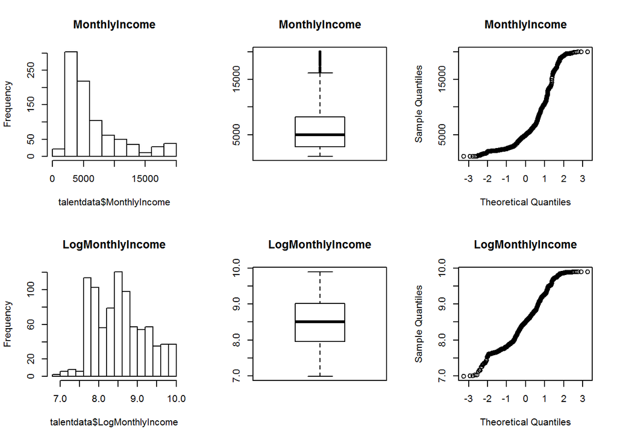

```r
par(mfrow=c(2,3))
hist(talentdata$MonthlyIncome, main = "MonthlyIncome")
OutVals1 = boxplot(talentdata$MonthlyIncome, main = "MonthlyIncome")$out
qqnorm(talentdata$MonthlyIncome, main = "MonthlyIncome")
talentdata$LogMonthlyIncome <- log(talentdata$MonthlyIncome)
hist(talentdata$LogMonthlyIncome, main = "LogMonthlyIncome")
OutVals = boxplot(talentdata$LogMonthlyIncome, main = "LogMonthlyIncome")$out
qqnorm(talentdata$LogMonthlyIncome, main = "LogMonthlyIncome")
```

```r
#Separate continuous and categorical variables for analysis
talentdata_conti <- talentdata[, !sapply(talentdata, is.factor)]
talentdata_categ <- talentdata[, sapply(talentdata, is.factor)]
```

#### Correlation of predictors

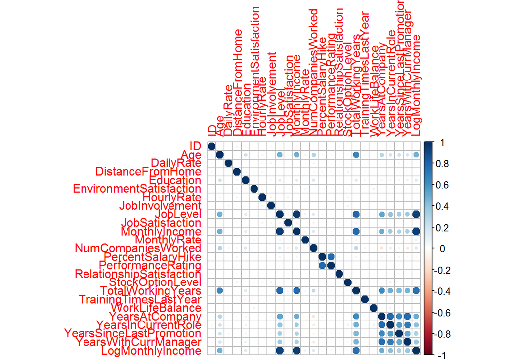

```r
library(corrplot)
#correlation of all the continuous variables, column of Attrition is first dropped.
correlation <- cor(talentdata_conti)
#correlation plot
corrplot(correlation)
```

From correlation plot of continuous variables, we can see that there are positive correlations between variables, LogMonthlyIncome, JobLevel, TotalWorkingYears, Age, YearsAtCompany, YearInCurrentRole, YearsSinceLastPromotion and YearsWithCurrentManager.

```r
library(GoodmanKruskal)
```

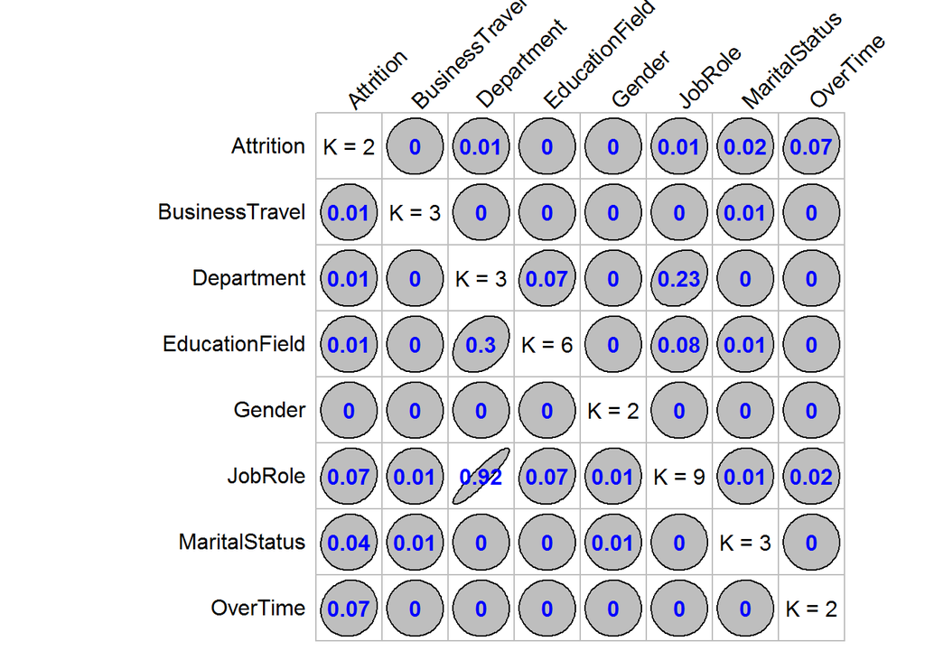

```r
cat_cor<- GKtauDataframe(talentdata_categ)
plot(cat_cor, corrColors = "blue")
```

From correlation plot of categorical variables, we can see there is a high correlation between Department and JobRole.

#### Check outliers in the dataset

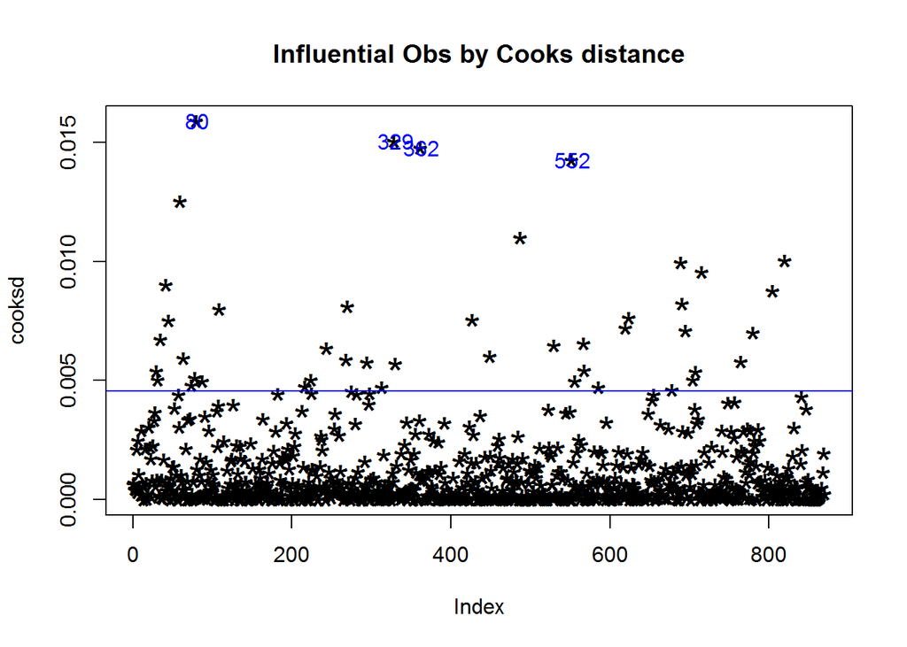

```r
mod <- lm(LogMonthlyIncome ~ ., data=talentdata[, -18])
cooksd <- cooks.distance(mod)
plot(cooksd, pch="*", cex=2, main="Influential Obs by Cooks distance")  # plot cook's distance
abline(h = 4*mean(cooksd, na.rm=T), col="blue")  # add cutoff line
text(x=1:length(cooksd)+1, y=cooksd, labels=ifelse(cooksd>12*mean(cooksd, na.rm=T),names(cooksd),""), col="Blue")  # add labels
```

```r
influential <- as.numeric(names(cooksd)[(cooksd > 12*mean(cooksd, na.rm=T))])  # influential row numbers
talentdata_outlier <- talentdata[influential, ]
talentdata_clean <- talentdata[-influential, ]
```

#### Data analysis using PCA analysis for continuous variables

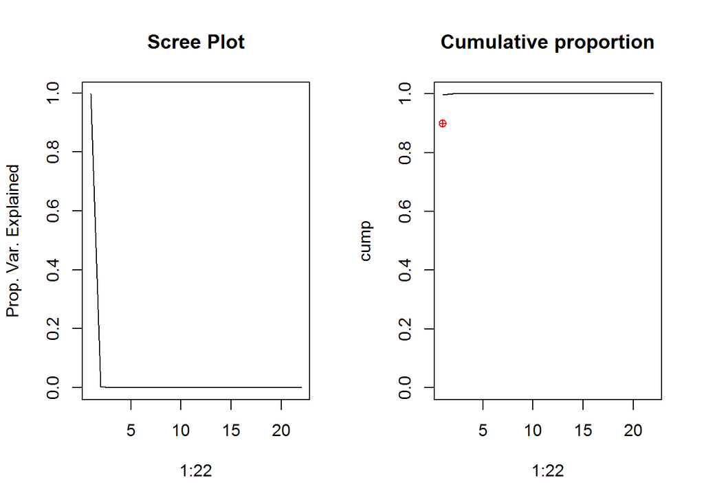

```r
library(stats)
#PCA analysis for continuous variables, except columns ID, MonthlyIncome and LogMonthlyIncome
pca.result<-prcomp(talentdata_conti[, -c(1, 11, 25)])
#Scree plot and determine the amount of PC's needed to retain approximately 90% of the total variation in the data set
par(mfrow=c(1,2))
eigenvalues<-(pca.result$sdev)^2
plot(1:22,eigenvalues/sum(eigenvalues),type="l",main="Scree Plot",ylab="Prop. Var. Explained")
cump<-cumsum(eigenvalues/sum(eigenvalues))
plot(1:22,cump,type="l",main="Cumulative proportion",ylim=c(0,1))
points(x=1, y=0.9, type = "p", pch=10, col = "red")
```

```r
#From scree plot and cumulative proportion plot, we can see only One derived PCs needed to retain approximately 90% of the total variation in the data set.
```

#### ggplots of PCs for visualization

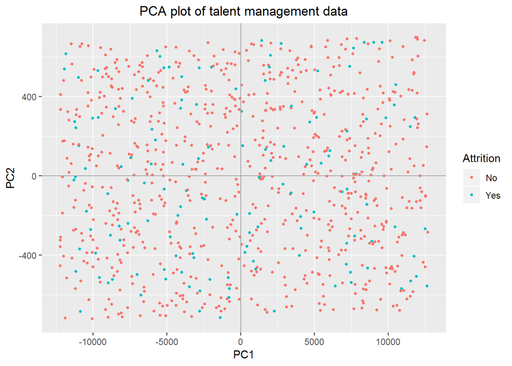

```r
library(ggplot2)
pca.scores<-pca.result$x
#pca.result$rotation
pca.scores<-data.frame(pca.scores)
pca.scores$Attrition <- talentdata$Attrition
#Use ggplot2 to plot the first few pc's
ggplot(data = pca.scores, aes(x = PC1, y = PC2)) +
  geom_point(aes(col=Attrition), size=1)+
  geom_hline(yintercept = 0, colour = "gray65") +
  geom_vline(xintercept = 0, colour = "gray65") +
 labs(title = "PCA plot of talent management data",color = "Attrition")+
  theme(plot.title = element_text(hjust = 0.5))
```

From the result of PCA plots, which do not have clear separation of response. We can not use LDA for the classification.

### Objective 1 Predict Attrition

#### Naive bayes model

```r
#Split train and test model
set.seed(345)
nr = 0.7*nrow(talentdata)
smp=sample(1:nrow(talentdata), nr)
train=talentdata[smp,]
test=talentdata[-smp,]
library(e1071)
library(caret)
model.naive <- naiveBayes(Attrition ~ ., data=train[,-c(1, 18)])
attrition.pred.naive <- predict(model.naive, test[,-c(1, 18)], type="class")
confusionMatrix(attrition.pred.naive, test$Attrition)
```

```
## Confusion Matrix and Statistics
##
##           Reference
## Prediction  No Yes
##        No  183  23
##        Yes  32  23
##
##                Accuracy : 0.7893
##                  95% CI : (0.7347, 0.8371)
##     No Information Rate : 0.8238
##     P-Value [Acc > NIR] : 0.9360
##
##                   Kappa : 0.3261
##  Mcnemar's Test P-Value : 0.2807
##
##             Sensitivity : 0.8512
##             Specificity : 0.5000
##          Pos Pred Value : 0.8883
##          Neg Pred Value : 0.4182
##              Prevalence : 0.8238
##          Detection Rate : 0.7011
##    Detection Prevalence : 0.7893
##       Balanced Accuracy : 0.6756
##
##        'Positive' Class : No
##
```

#### Train model with Naive bayes method and get importance of predictors

```r
#Prepare training scheme
control <- trainControl(method="repeatedcv", number=10, repeats=3, classProbs = TRUE)
set.seed(345)
#Train the model
model.naive.t <- train( Attrition ~ ., data=train[, -c(1,18)], method="naive_bayes", trControl=control)
attrition.pred.naive.t <- predict(model.naive.t, test[-c(1,18)])
confusionMatrix(attrition.pred.naive.t, test$Attrition)
```

```
## Confusion Matrix and Statistics
##
##           Reference
## Prediction  No Yes
##        No  215  46
##        Yes   0   0
##
##                Accuracy : 0.8238
##                  95% CI : (0.772, 0.868)
##     No Information Rate : 0.8238
##     P-Value [Acc > NIR] : 0.5393
##
##                   Kappa : 0
##  Mcnemar's Test P-Value : 3.247e-11
##
##             Sensitivity : 1.0000
##             Specificity : 0.0000
##          Pos Pred Value : 0.8238
##          Neg Pred Value :    NaN
##              Prevalence : 0.8238
##          Detection Rate : 0.8238
##    Detection Prevalence : 1.0000
##       Balanced Accuracy : 0.5000
##
##        'Positive' Class : No
##
```

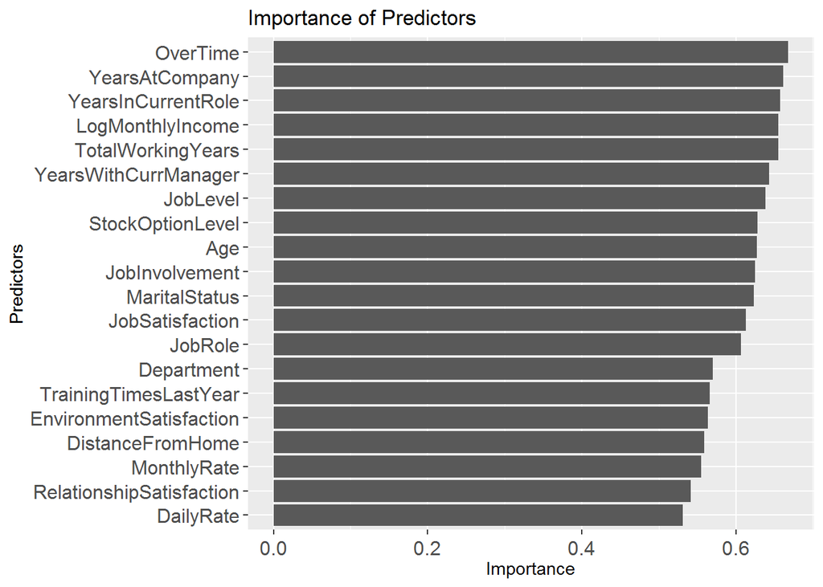

```r
#Top 10 Glmnet predictor ranking
importance.naive.t <- varImp(model.naive.t, scale=FALSE)
rank.naive.t <- importance.naive.t$importance
write.csv(rank.naive.t, "rank.naive.t.csv")
rank.naive.t <- read.csv("rank.naive.t.csv", header=TRUE)
colnames(rank.naive.t) <- c("Predictors", "Importance")
rank.naive.t <- rank.naive.t[order(rank.naive.t$Importance, decreasing = TRUE),]
ggplot(rank.naive.t[1:20,], aes(x=reorder(Predictors, Importance),y=Importance)) + geom_bar(stat = "identity") + coord_flip() + labs(title="Importance of Predictors", x="Predictors", y="Importance") +theme(axis.text.x=element_text(hjust=0.5, vjust=0.5, size = 12))+theme(axis.text.y=element_text(size = 12))
```

#### Custom Naive Bayes model

```r
#Split train and test model
set.seed(345)
nr = 0.7*nrow(talentdata)
smp=sample(1:nrow(talentdata), nr)
train=talentdata[smp,]
test=talentdata[-smp,]
library(e1071)
library(caret)
model.naive.ct <- naiveBayes(Attrition ~ OverTime + YearsAtCompany + YearsInCurrentRole+LogMonthlyIncome+TotalWorkingYears+YearsWithCurrManager+JobLevel+StockOptionLevel+Age, data=train)
attrition.pred.naive.ct <- predict(model.naive.ct, test, type="class")
confusionMatrix(attrition.pred.naive.ct, test$Attrition)
```

```
## Confusion Matrix and Statistics
##
##           Reference
## Prediction  No Yes
##        No  177  19
##        Yes  38  27
##
##                Accuracy : 0.7816
##                  95% CI : (0.7265, 0.8302)
##     No Information Rate : 0.8238
##     P-Value [Acc > NIR] : 0.96636
##
##                   Kappa : 0.3529
##  Mcnemar's Test P-Value : 0.01712
##
##             Sensitivity : 0.8233
##             Specificity : 0.5870
##          Pos Pred Value : 0.9031
##          Neg Pred Value : 0.4154
##              Prevalence : 0.8238
##          Detection Rate : 0.6782
##    Detection Prevalence : 0.7510
##       Balanced Accuracy : 0.7051
##
##        'Positive' Class : No
##
```

#### Naive Bayes model After outlier removal

```r
#Split train and test model
set.seed(345)
nr = 0.7*nrow(talentdata_clean)
smp=sample(1:nrow(talentdata_clean), nr)
train_clean=talentdata_clean[smp,]
test_clean=talentdata_clean[-smp,]

library(e1071)
model.naive2 <- naiveBayes(Attrition ~ ., data=train_clean[,-c(1,18)])
attrition.pred.naive2 <- predict(model.naive2, test_clean[,-c(1,18)], type="class")
confusionMatrix(attrition.pred.naive2, test_clean$Attrition)
```

```
## Confusion Matrix and Statistics
##
##           Reference
## Prediction  No Yes
##        No  171  19
##        Yes  35  35
##
##                Accuracy : 0.7923
##                  95% CI : (0.7379, 0.84)
##     No Information Rate : 0.7923
##     P-Value [Acc > NIR] : 0.53635
##
##                   Kappa : 0.4311
##  Mcnemar's Test P-Value : 0.04123
##
##             Sensitivity : 0.8301
##             Specificity : 0.6481
##          Pos Pred Value : 0.9000
##          Neg Pred Value : 0.5000
##              Prevalence : 0.7923
##          Detection Rate : 0.6577
##    Detection Prevalence : 0.7308
##       Balanced Accuracy : 0.7391
##
##        'Positive' Class : No
##
```

The removal of outliers can improve the specification and total accuracy.

#### Train model with knn and get importance of predictors

```r
#Prepare training scheme
control <- trainControl(method="repeatedcv", number=10, repeats=3)
set.seed(345)
#Train the model
model.knn <- train( Attrition ~ ., data=train[, -c(1,18)], method="knn", trControl=control)
attrition.pred.knn <- predict(model.knn, test[-c(1,18)])
confusionMatrix(attrition.pred.knn, test$Attrition)
```

```
## Confusion Matrix and Statistics
##
##           Reference
## Prediction  No Yes
##        No  213  46
##        Yes   2   0
##
##                Accuracy : 0.8161
##                  95% CI : (0.7637, 0.8612)
##     No Information Rate : 0.8238
##     P-Value [Acc > NIR] : 0.663
##
##                   Kappa : -0.0149
##  Mcnemar's Test P-Value : 5.417e-10
##
##             Sensitivity : 0.9907
##             Specificity : 0.0000
##          Pos Pred Value : 0.8224
##          Neg Pred Value : 0.0000
##              Prevalence : 0.8238
##          Detection Rate : 0.8161
##    Detection Prevalence : 0.9923
##       Balanced Accuracy : 0.4953
##
##        'Positive' Class : No
##
```

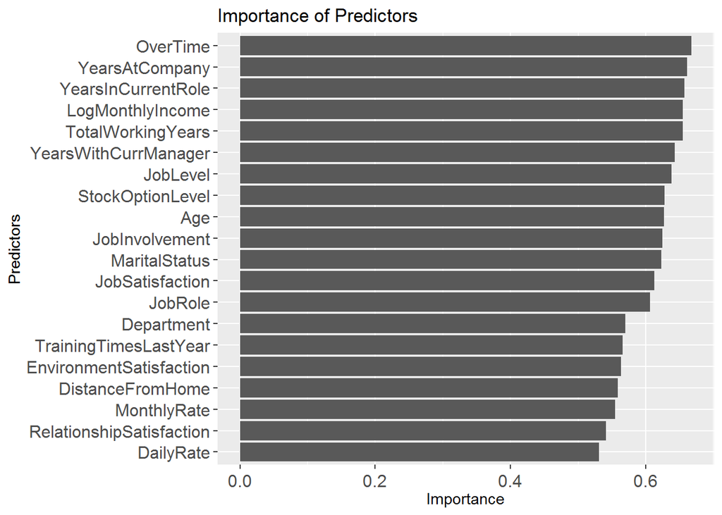

```r
#Top 10 predictor ranking
importance.knn <- varImp(model.knn, scale=FALSE)
rank.knn <- importance.knn$importance
write.csv(rank.knn, "rank.knn.csv")
rank.knn <- read.csv("rank.knn.csv", header=TRUE)
colnames(rank.knn) <- c("Predictors", "Importance")
rank.knn <- rank.knn[order(rank.knn$Importance, decreasing = TRUE),]
ggplot(rank.knn[1:20,], aes(x=reorder(Predictors, Importance),y=Importance)) + geom_bar(stat = "identity") + coord_flip() + labs(title="Importance of Predictors", x="Predictors", y="Importance") +theme(axis.text.x=element_text(hjust=0.5, vjust=0.5, size = 12))+theme(axis.text.y=element_text(size = 12))
```

#### Custom knn model

```r
#Split train and test model

talentdata_knn <- talentdata
talentdata_knn$OverTime<- revalue(talentdata_knn$OverTime, c("Yes"="1", "No"="0"))
talentdata_knn_conti <- talentdata_knn[, !sapply(talentdata_knn, is.factor)]
talentdata_knn_conti$Attrition <- talentdata$Attrition
set.seed(345)
nr = 0.7*nrow(talentdata_knn_conti)
smp=sample(1:nrow(talentdata_knn_conti), nr)
train_knn=talentdata_knn_conti[smp,]
test_knn=talentdata_knn_conti[-smp,]
library(class)
knn.3 = class::knn(train_knn[,-26], test_knn[, -26], train_knn$Attrition, k=3)
test_knn$AttritionPred3 = knn.3
confusionMatrix(table(test_knn$AttritionPred3, test_knn$Attrition))
```

```
## Confusion Matrix and Statistics
##
##
##        No Yes
##   No  198  43
##   Yes  17   3
##
##                Accuracy : 0.7701
##                  95% CI : (0.7142, 0.8197)
##     No Information Rate : 0.8238
##     P-Value [Acc > NIR] : 0.988893
##
##                   Kappa : -0.0178
##  Mcnemar's Test P-Value : 0.001249
##
##             Sensitivity : 0.92093
##             Specificity : 0.06522
##          Pos Pred Value : 0.82158
##          Neg Pred Value : 0.15000
##              Prevalence : 0.82375
##          Detection Rate : 0.75862
##    Detection Prevalence : 0.92337
##       Balanced Accuracy : 0.49307
##
##        'Positive' Class : No
##
```

#### Prediction for Attrition

```r
#Use as much data as possible for the naive bayes model for prediction
model.naive3 <- naiveBayes(Attrition ~ ., data=talentdata_clean[,-c(1, 18)])
val_attrition$LogMonthlyIncome <- log(val_attrition$MonthlyIncome)
AttritionPred <- predict(model.naive3, val_attrition, type="class")
attrition.pred <- data.frame("ID"=val_attrition$ID, AttritionPred)
write.csv(attrition.pred, "Case2PredictionsZheng Attrition.csv")
```

### Objective 2 Predict MonthlyIncome

#### train model with glmnet to find importance of predictors

```r
library(caret)
#Prepare training scheme
control <- trainControl(method="repeatedcv", number=10, repeats=3)
#Train the model, lasso
model.glmnet <- train(LogMonthlyIncome ~ ., data=train[, -c(3,18)], method="glmnet", trControl=control)
#Predicted
LogMonthlyIncome.pred.glmnet<-predict(model.glmnet,newdata=test[, -c(3,18)])
#Check RMSE for Linear Regression Model
library(Metrics)
rmse(test$MonthlyIncome,exp(LogMonthlyIncome.pred.glmnet))
```

```
## [1] 1492.278
```

#### Predictor importance ranking

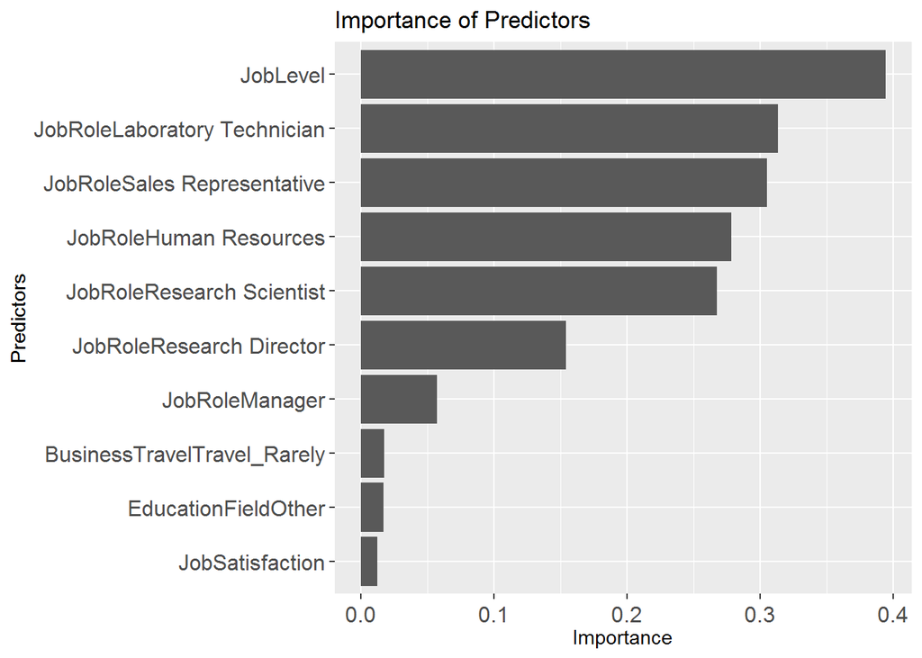

```r
#Top 10 Glmnet predictor ranking
importance.glmnet <- varImp(model.glmnet, scale=FALSE)
rank.glmnet <- importance.glmnet$importance
write.csv(rank.glmnet, "rank.glmnet.csv")
rank.glmnet <- read.csv("rank.glmnet.csv", header=TRUE)
colnames(rank.glmnet) <- c("Predictors", "Importance")
rank.glmnet <- rank.glmnet[order(rank.glmnet$Importance, decreasing = TRUE),]
ggplot(rank.glmnet[1:10,], aes(x=reorder(Predictors, Importance),y=Importance)) + geom_bar(stat = "identity") + coord_flip() + labs(title="Importance of Predictors", x="Predictors", y="Importance") +theme(axis.text.x=element_text(hjust=0.5, vjust=0.5, size = 12))+theme(axis.text.y=element_text(size = 12))
```

From the Predictor Importance plot, we can see the top two predictors are JobLevel and JobRole, customize the linear model using only these two predictors.

#### Custom Model

```r
model.lm <- lm(LogMonthlyIncome ~ JobLevel + JobRole + JobLevel*JobRole, data=train)
#Predicted
LogMonthlyIncome.pred.lm<-predict(model.lm,newdata=test)
#RMSE
rmse(test$MonthlyIncome,exp(LogMonthlyIncome.pred.lm))
```

```
## [1] 1091.801
```

```r
summary(model.lm)
```

```
##
## Call:
## lm(formula = LogMonthlyIncome ~ JobLevel + JobRole + JobLevel *
##     JobRole, data = train)
##
## Residuals:
##      Min       1Q   Median       3Q      Max
## -0.85814 -0.12616 -0.00498  0.12039  0.63316
##
## Coefficients:
##                                         Estimate Std. Error t value
## (Intercept)                             7.866422   0.133215  59.051
## JobLevel                                0.412544   0.053395   7.726
## JobRoleHuman Resources                 -0.519891   0.184603  -2.816
## JobRoleLaboratory Technician           -0.419648   0.144993  -2.894
## JobRoleManager                          1.019146   0.284631   3.581
## JobRoleManufacturing Director          -0.143016   0.170983  -0.836
## JobRoleResearch Director                0.997975   0.225892   4.418
## JobRoleResearch Scientist              -0.541886   0.147394  -3.676
## JobRoleSales Executive                 -0.190719   0.157762  -1.209
## JobRoleSales Representative            -0.415198   0.213596  -1.944
## JobLevel:JobRoleHuman Resources         0.112073   0.113965   0.983
## JobLevel:JobRoleLaboratory Technician   0.027915   0.067955   0.411
## JobLevel:JobRoleManager                -0.213997   0.078712  -2.719
## JobLevel:JobRoleManufacturing Director  0.049867   0.068040   0.733
## JobLevel:JobRoleResearch Director      -0.208332   0.070507  -2.955
## JobLevel:JobRoleResearch Scientist      0.183001   0.073993   2.473
## JobLevel:JobRoleSales Executive         0.067309   0.064340   1.046
## JobLevel:JobRoleSales Representative    0.007884   0.164093   0.048
##                                        Pr(>|t|)
## (Intercept)                             < 2e-16 ***
## JobLevel                               4.77e-14 ***
## JobRoleHuman Resources                 0.005021 **
## JobRoleLaboratory Technician           0.003941 **
## JobRoleManager                         0.000371 ***
## JobRoleManufacturing Director          0.403248
## JobRoleResearch Director               1.19e-05 ***
## JobRoleResearch Scientist              0.000258 ***
## JobRoleSales Executive                 0.227184
## JobRoleSales Representative            0.052388 .
## JobLevel:JobRoleHuman Resources        0.325813
## JobLevel:JobRoleLaboratory Technician  0.681378
## JobLevel:JobRoleManager                0.006746 **
## JobLevel:JobRoleManufacturing Director 0.463908
## JobLevel:JobRoleResearch Director      0.003254 **
## JobLevel:JobRoleResearch Scientist     0.013670 *
## JobLevel:JobRoleSales Executive        0.295920
## JobLevel:JobRoleSales Representative   0.961695
## ---
## Signif. codes:  0 '***' 0.001 '**' 0.01 '*' 0.05 '.' 0.1 ' ' 1
##
## Residual standard error: 0.2136 on 591 degrees of freedom
## Multiple R-squared:  0.8947, Adjusted R-squared:  0.8917
## F-statistic: 295.4 on 17 and 591 DF,  p-value: < 2.2e-16
```

#### Diagnostic plots of linear model

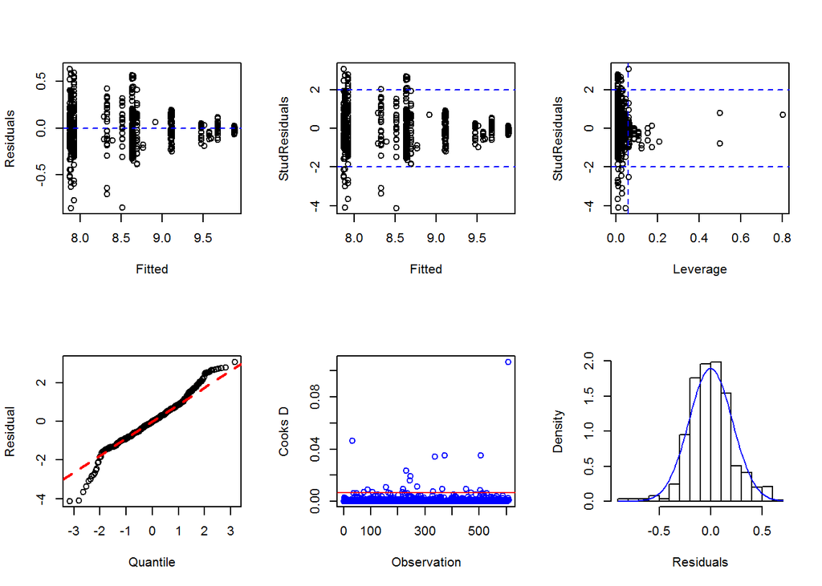

```r
#Diagnostic plots for the model
mlrplots(model.lm)
```

#### Custom Model after removal of outliers

```r
model.lm.ct <- lm(LogMonthlyIncome ~ JobLevel + JobRole + JobLevel*JobRole, data=train_clean)
#Predicted
LogMonthlyIncome.pred.lm.ct<-predict(model.lm.ct,newdata=test_clean)
#RMSE
rmse(test_clean$MonthlyIncome,exp(LogMonthlyIncome.pred.lm.ct))
```

```
## [1] 1001.044
```

```r
summary(model.lm.ct)
```

```
##
## Call:
## lm(formula = LogMonthlyIncome ~ JobLevel + JobRole + JobLevel *
##     JobRole, data = train_clean)
##
## Residuals:
##      Min       1Q   Median       3Q      Max
## -0.88882 -0.13470 -0.00123  0.12126  0.58539
##
## Coefficients:
##                                         Estimate Std. Error t value
## (Intercept)                             7.860019   0.118183  66.507
## JobLevel                                0.409238   0.046792   8.746
## JobRoleHuman Resources                 -0.416350   0.284042  -1.466
## JobRoleLaboratory Technician           -0.423828   0.133203  -3.182
## JobRoleManager                          0.989866   0.277657   3.565
## JobRoleManufacturing Director          -0.136457   0.168537  -0.810
## JobRoleResearch Director                0.969986   0.212834   4.557
## JobRoleResearch Scientist              -0.570633   0.136327  -4.186
## JobRoleSales Executive                 -0.178192   0.144578  -1.232
## JobRoleSales Representative            -0.634956   0.210200  -3.021
## JobLevel:JobRoleHuman Resources         0.001496   0.235711   0.006
## JobLevel:JobRoleLaboratory Technician   0.048272   0.064635   0.747
## JobLevel:JobRoleManager                -0.202049   0.075111  -2.690
## JobLevel:JobRoleManufacturing Director  0.056837   0.068598   0.829
## JobLevel:JobRoleResearch Director      -0.197011   0.065261  -3.019
## JobLevel:JobRoleResearch Scientist      0.225752   0.073365   3.077
## JobLevel:JobRoleSales Executive         0.066853   0.058424   1.144
## JobLevel:JobRoleSales Representative    0.221117   0.167600   1.319
##                                        Pr(>|t|)
## (Intercept)                             < 2e-16 ***
## JobLevel                                < 2e-16 ***
## JobRoleHuman Resources                 0.143237
## JobRoleLaboratory Technician           0.001541 **
## JobRoleManager                         0.000393 ***
## JobRoleManufacturing Director          0.418467
## JobRoleResearch Director               6.30e-06 ***
## JobRoleResearch Scientist              3.28e-05 ***
## JobRoleSales Executive                 0.218258
## JobRoleSales Representative            0.002631 **
## JobLevel:JobRoleHuman Resources        0.994940
## JobLevel:JobRoleLaboratory Technician  0.455460
## JobLevel:JobRoleManager                0.007348 **
## JobLevel:JobRoleManufacturing Director 0.407695
## JobLevel:JobRoleResearch Director      0.002648 **
## JobLevel:JobRoleResearch Scientist     0.002187 **
## JobLevel:JobRoleSales Executive        0.252981
## JobLevel:JobRoleSales Representative   0.187578
## ---
## Signif. codes:  0 '***' 0.001 '**' 0.01 '*' 0.05 '.' 0.1 ' ' 1
##
## Residual standard error: 0.2212 on 588 degrees of freedom
## Multiple R-squared:  0.8862, Adjusted R-squared:  0.8829
## F-statistic: 269.3 on 17 and 588 DF,  p-value: < 2.2e-16
```

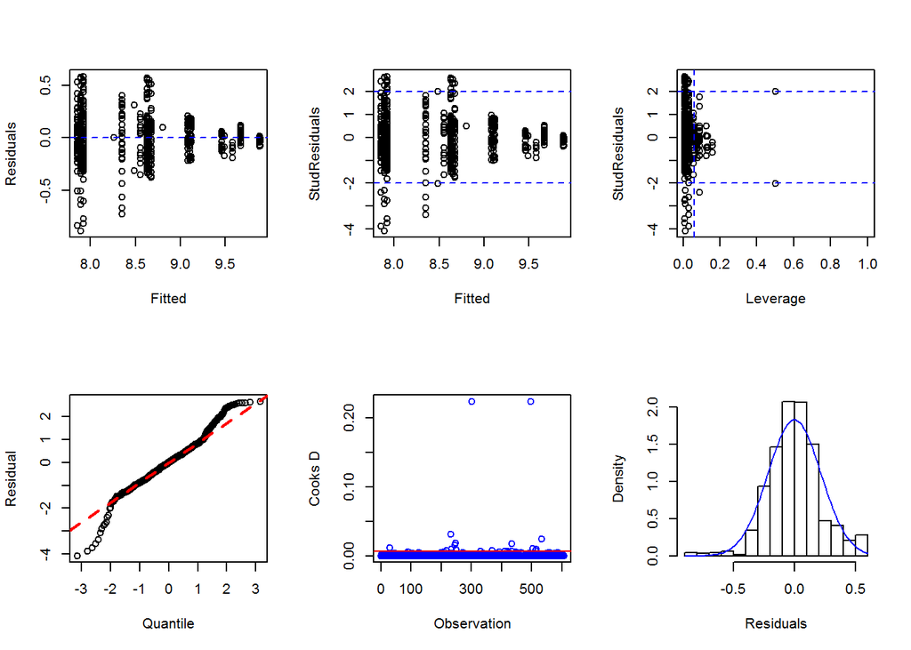

```r
#Diagnostic plots for the model
mlrplots(model.lm.ct)
```

#### Prediction for MonthlyIncome

The removal of outliers can reduce RMSE, but without further validation, it may not be a good idea to drop outliers. Here we use the custom linear model for the prediction.

```r
val_salary$LogMonthlyIncome <- log(val_attrition$MonthlyIncome)
SalaryPred <- predict(model.lm, val_salary[,-c(1,18)])
MonthlyIncome <- exp(SalaryPred)
salary.pred <- data.frame("ID"=val_salary$ID, MonthlyIncome)
write.csv(salary.pred, "Case2PredictionsZheng Salary.csv")
```